# 219000429_GY7708_CW2

Inner join is used to join the cluster_frequency and joy. Using ggplot a simple plotted to display the clusters which show more joy emotions. The cluster 5 has more number of joy words which indicates the articles in the cluster 5 geographical areas has more Joy sentiment words.

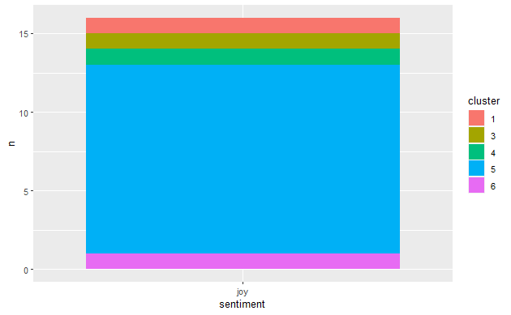

```r
innerJoinDf <- inner_join(cluster_frequency,joy,by="word")
innerJoinDf %>%
  count(cluster, sentiment) %>%
  ggplot() +
    geom_bar(aes(x = sentiment, y = n, fill = cluster), stat = 'identity')
```

The sentiment value of the each page_name is calculated and arranged in descending order.

```r
innerJoinDf %>%
  group_by(page_name) %>%
  summarise(sentiment_value = sum(value)) %>%
  arrange(desc(sentiment_value))
```

[output not shown]

[output cut: 155 more lines]

The emotions sentiments are displayed using the nrc sentiment, from wiki_text data the count of the each nrc sentiments are calculated for all the articles and the count is displayed.

```r
nrc_senti <- get_sentiments("nrc")

wiki_text%>%
  inner_join(nrc_senti) %>%
  count(sentiment, sort = TRUE)
```

| sentiment | n |
| --- | --- |
| positive | 1292 |
| trust | 884 |
| anticipation | 476 |
| negative | 442 |
| joy | 397 |
| fear | 230 |
| anger | 173 |
| sadness | 171 |
| disgust | 96 |
| surprise | 90 |

Using the bing sentiments, the words are separated into negative and positive sentiments and the positive and negative sentiments are displayed according to the words in the wiki_text and its count is calculated .

```r
bing_word_counts <- wiki_text %>%
  inner_join(get_sentiments("bing")) %>%
  count(word, sentiment, sort = TRUE) %>%
  ungroup()
bing_word_counts
```

| word | sentiment | n |
| --- | --- | --- |
| lies | negative | 35 |
| restored | positive | 12 |
| rich | positive | 12 |
| strict | negative | 12 |
| trust | positive | 12 |
| important | positive | 11 |
| outstanding | positive | 10 |
| steep | negative | 10 |
| well | positive | 10 |
| beauty | positive | 9 |

[output cut: 212 more lines]

Using the ggplot, the negative and positive sentiments are plotted using the bing_word_count.

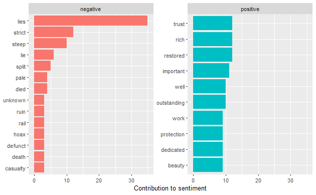

```r
bing_word_counts %>%
  group_by(sentiment) %>%
  slice_max(n, n = 10) %>%
  ungroup() %>%
  mutate(word = reorder(word, n)) %>%
  ggplot(aes(n, word, fill = sentiment)) +
  geom_col(show.legend = FALSE) +
  facet_wrap(~sentiment, scales = "free_y") +
  labs(x = "Contribution to sentiment",
       y = NULL)
```

The lexicon for the stopwords are calculated and stored in the custom_stop_words.

```r
custom_stop_words <- bind_rows(tibble(word = c("miss"),
                                      lexicon = c("custom")),
                               stop_words)
```

Using the wordcloud, the words from the wiki_text except the stopwords are arranged in the form of cloud.

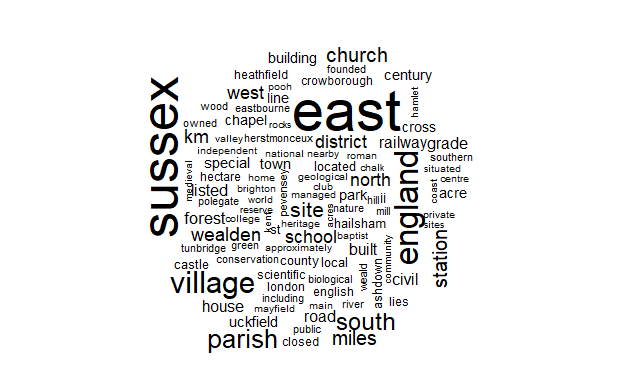

```r
wiki_text %>%
  anti_join(stop_words) %>%
  count(word) %>%
  with(wordcloud(word, n, max.words = 100))
```

The positive and the negative sentiments calculated from the wiki_text data set are compared and displayed using the cloud format.

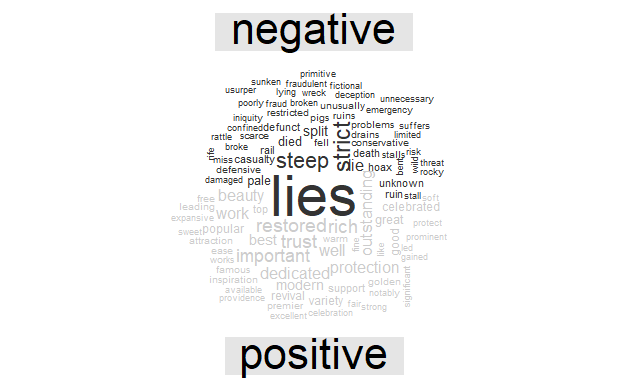

```r
library(reshape2)

wiki_text %>%
  inner_join(get_sentiments("bing")) %>%
  count(word, sentiment, sort = TRUE) %>%
  acast(word ~ sentiment, value.var = "n", fill = 0) %>%
  comparison.cloud(colors = c("gray20", "gray80"),
                   max.words = 100)
```

The negative and positive sentiment counts are calculated for each page_name and its percentage is displayed.

```r
sentiment_counts <- wiki_text %>%
  # implement sentiment analysis using the "bing" lexicon
  inner_join(get_sentiments("bing")) %>%
  # count the number of words by title, genre, and sentiment
  count(page_name,  sentiment)
sentiment_counts %>%
  group_by(page_name) %>%
  # find the total number of words in each play
  mutate(total = sum(n),
         percent = n / total) %>%
  # filter the results for only negative sentiment
  filter(sentiment == "negative") %>%
  arrange(percent)
```

| page_name | sentiment | n | total | percent |
| --- | --- | --- | --- | --- |
| St_George's_Church,_Polegate | negative | 1 | 6 | 0.1666667 |
| Ashdown_Forest | negative | 3 | 15 | 0.2000000 |
| Ashdown_Forest_Llama_Park | negative | 3 | 15 | 0.2000000 |
| England's_Medieval_Festival | negative | 1 | 5 | 0.2000000 |
| Eridge_railway_station | negative | 1 | 5 | 0.2000000 |
| Lullington_Church | negative | 1 | 5 | 0.2000000 |
| Bingletts_Wood | negative | 1 | 4 | 0.2500000 |
| Firle_Hill_Climb | negative | 1 | 4 | 0.2500000 |
| Long_Man_of_Wilmington | negative | 1 | 4 | 0.2500000 |
| River_Uck | negative | 1 | 4 | 0.2500000 |

[output cut: 99 more lines]

## Result

The sentiment analysis is successfully carried for the words in all the articles given in the Wealden LAD. From the output of the sentiment analysis code, various results can be seen. Which shows various lexicon and its uses in the analysis. Using the sentiment analysis the areas with more positive emotions and negative emotions can be filtered using the articles written in the wikipedia using the coordinates. Using the sentiment analysis various analysis can be carried to view the words categorized in the binary fashion. From the result of cluster_frequency and the nrc lexicon, the cluster 5 has more number of positive emotion indicating words written in the articles listed under the cluster 5. Using the R libraries the analysis has been simple and easy to carry out. The spatial frequency analysis done using the wikipedia articles listed under the Wealden. The results of the code shows the frequency analysis and sentiment analysis carried out spatially.